# Coronavirus Time Series Analysis

# Introduction

The current date of this analysis is March 16, 2020.

All code and data can be found on [Github](https://github.com/howardnewyork/corona).

# Summary of Results

# Methodology

Software: I used [Greta](https://greta-stats.org/index.html) and [Greta GP](https://github.com/greta-dev/greta.gp) to conduct a Bayesian analysis.

Models: The *basic model* is binomial model with a uniform prior assumption on the risk probability. For the youngest and very oldest ages there is very little data and this prior influences the results.

I developed a model combining all age groups and a model that analyzed each age group separately. For the latter, I used two types of models: 1. The first model assumes each age category is independent from the others. 2. The second model assumes a correlation structure between each age category. This was achieved by applying a latent Gaussian Process over the age-dependent risk parameters, using a RBF (radial basis function) kernel. I tested two GP models.

# Recommended Actions

*Disclaimer*: I am not an epidemiologist so my analysis is very much one of an armchair scientist. However, I am an actuary, so I know a thing or two about risk rates.

# Data Sources

[Johns Hopkins COID-19 Data Repository](https://github.com/CSSEGISandData/COVID-19/compare?expand=1)

# Initialize Data

```r
# Time Series Analysis of Survival from Breast Cancer


library(rstan)
options(mc.cores = min(8,parallel::detectCores()))
rstan_options(auto_write = TRUE)

library(ggplot2)
library(dplyr)
library(purrr)
library(tidyr)
library(readr)
library(stringr)
library (bayesplot)
library(lubridate)
library(corrplot)

# MCMC Pars
n_samples_base = 1000
warmup_base = 250
chains_base = 20

# Set Directories
working_dir = paste0(getwd(), "/")
data_dir = paste0(working_dir, "data/")
output_dir = paste0(working_dir, "output/")
stan_dir = paste0(working_dir, "stan/")

selected_countries = c("Germany", "France", "Spain", "China", "Australia", "US", "South Korea", "Italy",  "United Kingdom")
selected_countries = c("Italy", "US", "Australia", "South Korea", "China")
cutoff= 100

# Load Data
corona_raw = read_csv(file = paste0(data_dir, "time_series_19_covid_2020_03_15.csv"))
head(corona_raw, 10)
```

| province_state | country | lat | long | 1/22/2020 | 1/23/2020 | 1/24/2020 | 1/25/2020 | 1/26/2020 | 1/27/2020 | 1/28/2020 | 1/29/2020 | 1/30/2020 | 1/31/2020 | 2/1/2020 | 2/2/2020 | 2/3/2020 | 2/4/2020 | 2/5/2020 | 2/6/2020 | 2/7/2020 | 2/8/2020 | 2/9/2020 | 2/10/2020 | 2/11/2020 | 2/12/2020 | 2/13/2020 | 2/14/2020 | 2/15/2020 | 2/16/2020 | … |
| --- | --- | --- | --- | --- | --- | --- | --- | --- | --- | --- | --- | --- | --- | --- | --- | --- | --- | --- | --- | --- | --- | --- | --- | --- | --- | --- | --- | --- | --- | --- |
| NA | Thailand | 15.0000 | 101.0000 | 2 | 3 | 5 | 7 | 8 | 8 | 14 | 14 | 14 | 19 | 19 | 19 | 19 | 25 | 25 | 25 | 25 | 32 | 32 | 32 | 33 | 33 | 33 | 33 | 33 | 34 | … |
| NA | Japan | 36.0000 | 138.0000 | 2 | 1 | 2 | 2 | 4 | 4 | 7 | 7 | 11 | 15 | 20 | 20 | 20 | 22 | 22 | 45 | 25 | 25 | 26 | 26 | 26 | 28 | 28 | 29 | 43 | 59 | … |
| NA | Singapore | 1.2833 | 103.8333 | 0 | 1 | 3 | 3 | 4 | 5 | 7 | 7 | 10 | 13 | 16 | 18 | 18 | 24 | 28 | 28 | 30 | 33 | 40 | 45 | 47 | 50 | 58 | 67 | 72 | 75 | … |
| NA | Nepal | 28.1667 | 84.2500 | 0 | 0 | 0 | 1 | 1 | 1 | 1 | 1 | 1 | 1 | 1 | 1 | 1 | 1 | 1 | 1 | 1 | 1 | 1 | 1 | 1 | 1 | 1 | 1 | 1 | 1 | … |
| NA | Malaysia | 2.5000 | 112.5000 | 0 | 0 | 0 | 3 | 4 | 4 | 4 | 7 | 8 | 8 | 8 | 8 | 8 | 10 | 12 | 12 | 12 | 16 | 16 | 18 | 18 | 18 | 19 | 19 | 22 | 22 | … |
| British Columbia | Canada | 49.2827 | -123.1207 | 0 | 0 | 0 | 0 | 0 | 0 | 1 | 1 | 1 | 1 | 1 | 1 | 1 | 1 | 2 | 2 | 4 | 4 | 4 | 4 | 4 | 4 | 4 | 4 | 4 | 4 | … |
| New South Wales | Australia | -33.8688 | 151.2093 | 0 | 0 | 0 | 0 | 3 | 4 | 4 | 4 | 4 | 4 | 4 | 4 | 4 | 4 | 4 | 4 | 4 | 4 | 4 | 4 | 4 | 4 | 4 | 4 | 4 | 4 | … |
| Victoria | Australia | -37.8136 | 144.9631 | 0 | 0 | 0 | 0 | 1 | 1 | 1 | 1 | 2 | 3 | 4 | 4 | 4 | 4 | 4 | 4 | 4 | 4 | 4 | 4 | 4 | 4 | 4 | 4 | 4 | 4 | … |
| Queensland | Australia | -28.0167 | 153.4000 | 0 | 0 | 0 | 0 | 0 | 0 | 0 | 1 | 3 | 2 | 3 | 2 | 2 | 3 | 3 | 4 | 5 | 5 | 5 | 5 | 5 | 5 | 5 | 5 | 5 | 5 | … |
| NA | Cambodia | 11.5500 | 104.9167 | 0 | 0 | 0 | 0 | 0 | 1 | 1 | 1 | 1 | 1 | 1 | 1 | 1 | 1 | 1 | 1 | 1 | 1 | 1 | 1 | 1 | 1 | 1 | 1 | 1 | 1 | … |

```r
corona = corona_raw %>%
  mutate(country = if_else(country == "Korea, South", "South Korea", country))  %>%
  select(-lat, -long, -province_state) %>%
  group_by(country) %>%
  summarise_all(sum) %>%
  gather(date, confirmed, -country) %>%
  group_by(country) %>%
  mutate(date = mdy(date)) %>%
  arrange(date) %>%
  mutate(growth = confirmed - lag(confirmed),
         growth_rate = log(confirmed / lag(confirmed))) %>%
  arrange(date) %>%
  mutate(growth_rate = ifelse(is.finite(growth_rate), growth_rate, NA))


corona_align = corona %>%
  filter(country %in% selected_countries,
         confirmed >=cutoff) %>%
  ungroup() %>%
  group_by(country) %>%
  mutate(day = date-first(date)+1) %>%
  select(country,confirmed, growth,growth_rate, date, day) %>%
  arrange(day)
corona_align
```

| country | confirmed | growth | growth_rate | date | day |
| --- | --- | --- | --- | --- | --- |
| China | 548 | NA | NA | 2020-01-22 | 1 days |
| South Korea | 104 | 73 | 1.2104036947 | 2020-02-20 | 1 days |
| Italy | 155 | 93 | 0.9162907319 | 2020-02-23 | 1 days |
| US | 118 | 20 | 0.1857171458 | 2020-03-03 | 1 days |
| Australia | 107 | 16 | 0.1619693279 | 2020-03-10 | 1 days |
| China | 643 | 95 | 0.1598694373 | 2020-01-23 | 2 days |
| South Korea | 204 | 100 | 0.6737290947 | 2020-02-21 | 2 days |
| Italy | 229 | 74 | 0.3902968866 | 2020-02-24 | 2 days |
| US | 149 | 31 | 0.2332616815 | 2020-03-04 | 2 days |
| Australia | 128 | 21 | 0.1792014295 | 2020-03-11 | 2 days |

[output cut: 110 more lines]

```r
corona
```

| country | date | confirmed | growth | growth_rate |
| --- | --- | --- | --- | --- |
| Afghanistan | 2020-01-22 | 0 | NA | NA |
| Albania | 2020-01-22 | 0 | NA | NA |
| Algeria | 2020-01-22 | 0 | NA | NA |
| Andorra | 2020-01-22 | 0 | NA | NA |
| Antigua and Barbuda | 2020-01-22 | 0 | NA | NA |
| Argentina | 2020-01-22 | 0 | NA | NA |
| Armenia | 2020-01-22 | 0 | NA | NA |
| Aruba | 2020-01-22 | 0 | NA | NA |
| Australia | 2020-01-22 | 0 | NA | NA |
| Austria | 2020-01-22 | 0 | NA | NA |

[output cut: 990 more lines]

```r
corona %>%  filter(country=="China")
```

| country | date | confirmed | growth | growth_rate |
| --- | --- | --- | --- | --- |
| China | 2020-01-22 | 548 | NA | NA |
| China | 2020-01-23 | 643 | 95 | 0.1598694373 |
| China | 2020-01-24 | 920 | 277 | 0.3582289458 |
| China | 2020-01-25 | 1406 | 486 | 0.4241304023 |
| China | 2020-01-26 | 2075 | 669 | 0.3892123603 |
| China | 2020-01-27 | 2877 | 802 | 0.3267869309 |
| China | 2020-01-28 | 5509 | 2632 | 0.6496350339 |
| China | 2020-01-29 | 6087 | 578 | 0.0997722310 |
| China | 2020-01-30 | 8141 | 2054 | 0.2907576731 |
| China | 2020-01-31 | 9802 | 1661 | 0.1856734239 |

[output cut: 44 more lines]

```r
corona %>%  filter(country=="Australia", confirmed >=10) %>% select(date, confirmed, growth_rate, growth_rate)
```

| country | date | confirmed | growth_rate |
| --- | --- | --- | --- |
| Australia | 2020-02-01 | 12 | 0.28768207 |
| Australia | 2020-02-02 | 12 | 0.00000000 |
| Australia | 2020-02-03 | 12 | 0.00000000 |
| Australia | 2020-02-04 | 13 | 0.08004271 |
| Australia | 2020-02-05 | 13 | 0.00000000 |
| Australia | 2020-02-06 | 14 | 0.07410797 |
| Australia | 2020-02-07 | 15 | 0.06899287 |
| Australia | 2020-02-08 | 15 | 0.00000000 |
| Australia | 2020-02-09 | 15 | 0.00000000 |
| Australia | 2020-02-10 | 15 | 0.00000000 |

[output cut: 34 more lines]

# Data Exploration

```r
ggplot(corona %>% filter(country %in% selected_countries)) +
  geom_line(aes(date,confirmed, color=country)) +
  labs(title = "Confirmed Cases by Country", x="date", y="Confirmed Cases")+
   scale_y_continuous( labels = scales::comma)
```

[output not shown]

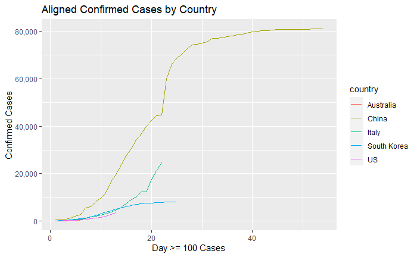

```r
ggplot(corona_align ) +
  geom_line(aes(day,confirmed, color=country)) +
  labs(title = "Aligned Confirmed Cases by Country", x=paste0(c("Day >= ", cutoff, " Cases"), collapse = ""), y="Confirmed Cases")+
   scale_y_continuous( labels = scales::comma)
```

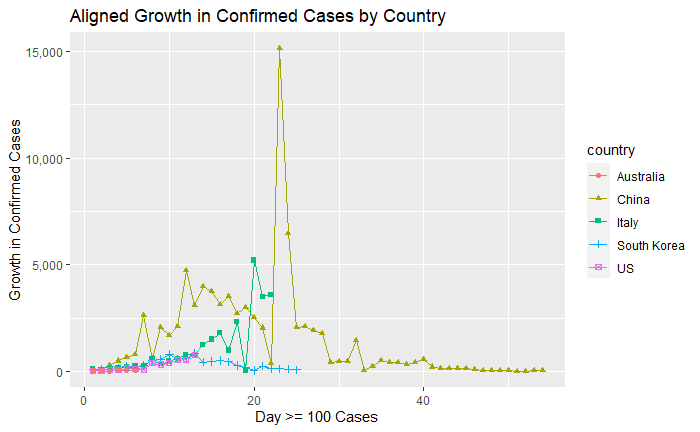

```r
ggplot(corona_align ) +
  geom_line(aes(day,growth, color=country)) +
  geom_point(aes(day,growth, color=country, shape=country)) +
  labs(title = "Aligned Growth in Confirmed Cases by Country", x=paste0(c("Day >= ", cutoff, " Cases"), collapse=""), y="Growth in Confirmed Cases")+
   scale_y_continuous( labels = scales::comma)
```

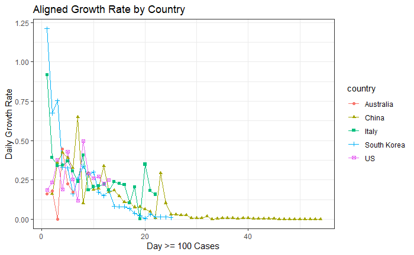

```r
ggplot(corona_align) +
  geom_line(aes(day,growth_rate, color=country)) +
  geom_point(aes(day,growth_rate, color=country, shape=country)) +
  labs(title = "Aligned Growth Rate by Country", x=paste0(c("Day >= ", cutoff, " Cases"), collapse=""), y="Daily Growth Rate")+
  theme_bw()
```

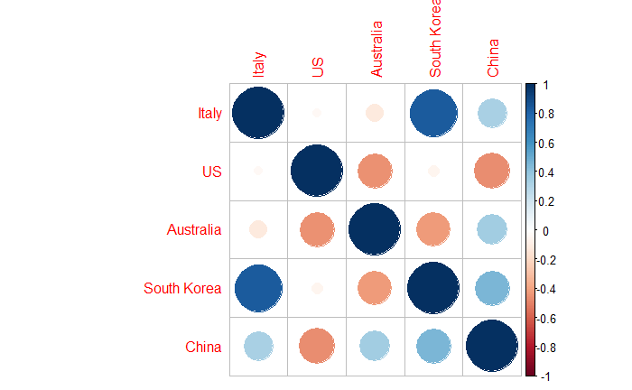

```r
corona_cor = corona_align %>%
  select(day, country, growth_rate) %>%
  pivot_wider(names_from = country, values_from = growth_rate) %>%
  select(-day) %>%
  cor(use = "pairwise.complete.obs")
corrplot(corona_cor[selected_countries, selected_countries])
```

```r
corona_align %>%
  group_by(country) %>%
  group_map(~lm(data = .x,  formula =  growth_rate ~ day ))
```

```
[[1]]

Call:
lm(formula = growth_rate ~ day, data = .x)

Coefficients:
(Intercept)          day
    0.13418      0.01799


[[2]]

Call:
lm(formula = growth_rate ~ day, data = .x)

Coefficients:
(Intercept)          day
   0.288048    -0.006921


[[3]]

Call:
lm(formula = growth_rate ~ day, data = .x)

Coefficients:
(Intercept)          day
    0.47042     -0.01723


[[4]]

Call:
lm(formula = growth_rate ~ day, data = .x)

Coefficients:
(Intercept)          day
    0.62276     -0.03076


[[5]]

Call:
lm(formula = growth_rate ~ day, data = .x)

Coefficients:
(Intercept)          day
   0.271233     0.000541
```

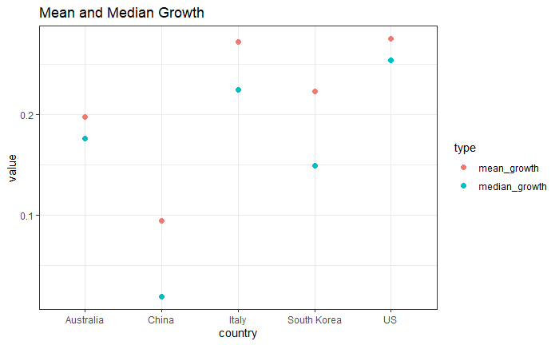

```r
ave_growth = corona_align %>%
  group_by(country) %>%
  summarize(mean_growth = mean(growth_rate, na.rm = T),
            median_growth = median(growth_rate, na.rm = T) )

ggplot(ave_growth %>% pivot_longer(names_to = "type", values_to = "value", -country)) +
  geom_point(aes(country, value, color=type), size=2)+
  labs(title = "Mean and Median Growth") +
  theme_bw()
```

```r
M= lm(data = corona_align, formula =  growth_rate ~ day + country)
summary(M)
```

```
Call:
lm(formula = growth_rate ~ day + country, data = corona_align)

Residuals:
     Min       1Q   Median       3Q      Max
-0.20190 -0.08960 -0.02022  0.04037  0.87332

Coefficients:
                    Estimate Std. Error t value Pr(>|t|)
(Intercept)         0.230439   0.061079   3.773 0.000259 ***
day                -0.009513   0.001227  -7.751 4.33e-12 ***
countryChina        0.130175   0.070969   1.834 0.069248 .
countryItaly        0.151197   0.069434   2.178 0.031517 *
countrySouth Korea  0.116154   0.068841   1.687 0.094309 .
countryUS           0.111169   0.073783   1.507 0.134681
---
Signif. codes:  0 ‘***’ 0.001 ‘**’ 0.01 ‘*’ 0.05 ‘.’ 0.1 ‘ ’ 1

Residual standard error: 0.1492 on 113 degrees of freedom
  (1 observation deleted due to missingness)
Multiple R-squared:  0.4525,    Adjusted R-squared:  0.4282
F-statistic: 18.68 on 5 and 113 DF,  p-value: 1.72e-13
```

```r
M = lm(data = corona_align, formula =  growth_rate ~ day + confirmed + country)
summary(M)
```

```
Call:
lm(formula = growth_rate ~ day + confirmed + country, data = corona_align)

Residuals:
     Min       1Q   Median       3Q      Max
-0.20319 -0.09870 -0.02966  0.04575  0.84755

Coefficients:
                     Estimate Std. Error t value Pr(>|t|)
(Intercept)         2.398e-01  6.151e-02   3.899 0.000165 ***
day                -1.228e-02  2.671e-03  -4.599 1.12e-05 ***
confirmed           1.704e-06  1.460e-06   1.168 0.245383
countryChina        1.058e-01  7.388e-02   1.431 0.155077
countryItaly        1.626e-01  7.001e-02   2.323 0.021988 *
countrySouth Korea  1.351e-01  7.063e-02   1.913 0.058251 .
countryUS           1.193e-01  7.399e-02   1.612 0.109769
---
Signif. codes:  0 ‘***’ 0.001 ‘**’ 0.01 ‘*’ 0.05 ‘.’ 0.1 ‘ ’ 1

Residual standard error: 0.149 on 112 degrees of freedom
  (1 observation deleted due to missingness)
Multiple R-squared:  0.4591,    Adjusted R-squared:  0.4301
F-statistic: 15.84 on 6 and 112 DF,  p-value: 4.133e-13
```

```r
M = lm(data = corona_align, formula =  growth_rate ~  confirmed + country)
summary(M)
```

```
Call:
lm(formula = growth_rate ~ confirmed + country, data = corona_align)

Residuals:
     Min       1Q   Median       3Q      Max
-0.24679 -0.08022 -0.00027  0.01969  0.96876

Coefficients:
                     Estimate Std. Error t value Pr(>|t|)
(Intercept)         1.979e-01  6.603e-02   2.998  0.00335 **
confirmed          -4.260e-06  7.268e-07  -5.861 4.63e-08 ***
countryChina        1.279e-01  8.002e-02   1.598  0.11282
countryItaly        1.019e-01  7.463e-02   1.366  0.17468
countrySouth Korea  4.415e-02  7.360e-02   0.600  0.54975
countryUS           8.186e-02  7.983e-02   1.025  0.30737
---
Signif. codes:  0 ‘***’ 0.001 ‘**’ 0.01 ‘*’ 0.05 ‘.’ 0.1 ‘ ’ 1

Residual standard error: 0.1617 on 113 degrees of freedom
  (1 observation deleted due to missingness)
Multiple R-squared:  0.3569,    Adjusted R-squared:  0.3285
F-statistic: 12.54 on 5 and 113 DF,  p-value: 1.084e-09
```

```r
corona_align = corona_align %>%
  filter(is.finite(growth_rate)) %>%
  mutate(smoothed = predict(loess(formula =  growth_rate ~ as.numeric(day), na.action = na.omit)))
```

[output not shown]

```r
corona_align
```

| country | confirmed | growth | growth_rate | date | day | smoothed |
| --- | --- | --- | --- | --- | --- | --- |
| South Korea | 104 | 73 | 1.2104036947 | 2020-02-20 | 1 days | 9.971085e-01 |
| Italy | 155 | 93 | 0.9162907319 | 2020-02-23 | 1 days | 6.845915e-01 |
| US | 118 | 20 | 0.1857171458 | 2020-03-03 | 1 days | 1.870171e-01 |
| Australia | 107 | 16 | 0.1619693279 | 2020-03-10 | 1 days | 1.619693e-01 |
| China | 643 | 95 | 0.1598694373 | 2020-01-23 | 2 days | 3.823627e-01 |
| South Korea | 204 | 100 | 0.6737290947 | 2020-02-21 | 2 days | 8.171636e-01 |
| Italy | 229 | 74 | 0.3902968866 | 2020-02-24 | 2 days | 5.738178e-01 |
| US | 149 | 31 | 0.2332616815 | 2020-03-04 | 2 days | 2.531801e-01 |
| Australia | 128 | 21 | 0.1792014295 | 2020-03-11 | 2 days | 1.792014e-01 |
| China | 920 | 277 | 0.3582289458 | 2020-01-24 | 3 days | 3.639574e-01 |

[output cut: 109 more lines]

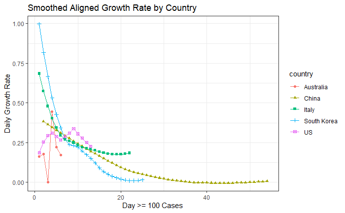

```r
ggplot(corona_align) +
  geom_line(aes(day,smoothed, color=country)) +
  geom_point(aes(day,smoothed, color=country, shape=country)) +
  labs(title = "Smoothed Aligned Growth Rate by Country", x=paste0(c("Day >= ", cutoff, " Cases"), collapse=""),
       y="Daily Growth Rate")+
  theme_bw()
```

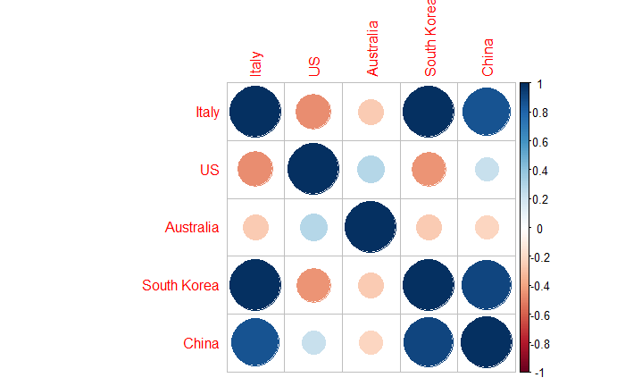

```r
corona_cor2 = corona_align %>%
  select(day, country, smoothed) %>%
  pivot_wider(names_from = country, values_from = smoothed) %>%
  select(-day) %>%
  cor(use = "pairwise.complete.obs")
corrplot(corona_cor2[selected_countries, selected_countries])
```

```r
#corr2 = corona_cor2
```

# Stan GP Analysis

Prepare input

```r
country_count = length(unique(corona_align$country))
N = nrow(corona_align)
N_pred = as.numeric(country_count * (max(corona_align$day) - min(corona_align$day)+1))


stan_list = list(
  N1 = N,  # historic data
  #N2= N_pred,  # predicted points
  N2= N,  # predicted points
  D=1, # Dimension of input values
  dimCat = country_count, # dimension of number oif unique categorical values

  # Historic Data
  x1 = matrix(as.numeric(corona_align$day), ncol = 1) ,  # input values (N1 x D matrix from R)
  x_cat1= as.numeric(as.factor(corona_align$country)),  # input values containing a categorical value
  y1 = corona_align$growth_rate,  # output values
  # Inputs for prediction

  # x2= matrix(rep(min(corona_align$day):max(corona_align$day), each = country_count), ncol=1),  # input values (N xD matrix from R)
  # x_cat2 =  rep(1:country_count, times = max(corona_align$day)),  # input values containing a categorical value
  x2 = matrix(as.numeric(corona_align$day), ncol = 1) ,  # input values (N1 x D matrix from R)
  x_cat2= as.numeric(as.factor(corona_align$country)),  # input values containing a categorical value

 # inputs for priors on parameters
 prior_eta = 2,
 prior_rho = c(5,5),
 prior_sigma = 1,
 prior_alpha =2
)
str(stan_list)
```

```
List of 13
 $ N1         : int 119
 $ N2         : int 119
 $ D          : num 1
 $ dimCat     : int 5
 $ x1         : num [1:119, 1] 1 1 1 1 2 2 2 2 2 3 ...
 $ x_cat1     : num [1:119] 4 3 5 1 2 4 3 5 1 2 ...
 $ y1         : num [1:119] 1.21 0.916 0.186 0.162 0.16 ...
 $ x2         : num [1:119, 1] 1 1 1 1 2 2 2 2 2 3 ...
 $ x_cat2     : num [1:119] 4 3 5 1 2 4 3 5 1 2 ...
 $ prior_eta  : num 2
 $ prior_rho  : num [1:2] 5 5
 $ prior_sigma: num 1
 $ prior_alpha: num 2
```

Run Stan Model

```r
mod = stan_model(file = paste0(stan_dir, "gp_mod1.stan"))
draws = sampling(object = mod, data = stan_list , chains = 8, iter = 1000, warmup=300)
```

Correlation Analysis

```r
summary(draws, pars = "lkj2")$summary
```

```
               mean      se_mean           sd       2.5%       25%       50%       75%     97.5%    n_eff
lkj2[1,1] 1.0000000          NaN 0.000000e+00 1.00000000 1.0000000 1.0000000 1.0000000 1.0000000      NaN
lkj2[1,2] 0.5638287 5.446352e-03 2.730749e-01 0.03837361 0.3503316 0.5960858 0.7973205 0.9711122 2513.925
lkj2[2,1] 0.5638287 5.446352e-03 2.730749e-01 0.03837361 0.3503316 0.5960858 0.7973205 0.9711122 2513.925
lkj2[2,2] 1.0000000 2.029191e-19 1.284948e-17 1.00000000 1.0000000 1.0000000 1.0000000 1.0000000 4009.826
               Rhat
lkj2[1,1]       NaN
lkj2[1,2] 1.0039354
lkj2[2,1] 1.0039354
lkj2[2,2] 0.9985704
```

```r
country_cor = matrix(summary(draws, pars = "lkj2")$summary[, "mean"], nrow = country_count)
rownames(country_cor) = country_names
colnames(country_cor) = country_names
```

### Greta Projection Analysis

#### Beta Binom Model: Single Parameter,

```r
# Identify the data input for Greta using the as_data function
library(onehot)
encoder = (onehot(as.data.frame(corona_align$country)))
predict(encoder,as.data.frame(corona_align$country))
```

[output not shown]

[output cut: 322 more lines]

```r
country_count = length(unique(corona_align$country))
N = nrow(corona_align)
country = as.matrix(predict(encoder,as.data.frame(corona_align$country)))
country_num = 1:country_count
country_num = country %*% country_num
index = matrix(1:(country_count^2), country_count, country_count)
country_rho_index = matrix(0, N, N)
for (i in 1:N){
  for (j in 1:N){
    country_rho_index[i,j] = index[country_num[i],country_num[j]]
  }
}
country_rho_index = c(country_rho_index)
growth_rate = as_data(corona_align$growth_rate)
day = as_data(as.numeric(corona_align$day))
country = as_data(country) # one hot encoded
country_num = as_data(country_num)
# Define the prior for the theta parameter
eta = lognormal(0,4)
rho_day = lognormal(0,4)
rho_country = lkj_correlation(eta = 1, dimension = country_count) *2 -1
rho_country_long = zeros(country_count^2, 1)
rho_country_long = rho_country
rho_country_index = rho_country_long[country_rho_index]
rho_country_kernel = zeros(N,N)
rho_country_kernel = rho_country_index
# kernel & GP
kernel = rbf(rho_day, eta_deaths)
```

[output not shown]

```r
# diagnostics
theta_names = colnames(draws_gp[[1]])
mcmc_trace(draws_gp, pars = theta_names[1:10])
mcmc_trace(draws_gp, pars = theta_names[11:11])
mcmc_intervals(draws_gp, pars = theta_names[1:10])
mcmc_intervals(draws_gp, theta_names[11:11])

summary(draws_gp)
```

```r
theta_post_gp =
  draws_gp %>%
  reduce(rbind) %>%
  as_tibble() %>%
  select(-eta_deaths)

colnames(theta_post_gp) =
  paste0(rep(c( "theta_deaths_"),
             each=categories) , 1:categories)
theta_post_gp = cbind(S=1:S,as_tibble(theta_post_gp)) %>%
  gather(posterior, value, -S) %>%
  mutate(risk_cat = as.factor(gsub(pattern = "_([^_]*)$","",(posterior))),
           age_cat = as.factor((as.numeric(extract_numeric(posterior)))*10-5))

theta_post_gp_sum = theta_post_gp %>%
  group_by(age_cat) %>%
  summarize(mean = mean(value),
            low = quantile(value, 0.1),
            high = quantile(value, 0.9)
            ) %>%
  gather(range, value, -mean, -age_cat)

ggplot(theta_post_gp_sum) +
  geom_point(aes(age_cat, mean, color = age_cat),size=2) +
  geom_line(aes(age_cat, value, group = age_cat)) +
  labs(title="Diamond Princess: Risk of Death", color="", y="Fatality Rate", x="Age") +
  theme_bw()



# ggplot(theta_post_gp ) +
#   geom_violin(aes(age_cat, value, fill = age_cat), alpha=0.5, draw_quantiles = c(0.1, 0.5, 0.9), scale = "width") +
#   labs(title="Diamond Princess: Risk of Death", color="", y="Fatality Rate", x="Age") +
#   ylim(0,.1)+
#   theme_bw()


ggplot(theta_post_gp_sum) +
  geom_point(aes(age_cat, mean, color = age_cat),size=2) +
  geom_line(aes(age_cat, value, group = age_cat)) +
  labs(title="Diamond Princess: Risk of Death\n with 80% Credible Interval", color="", y="Fatality Rate", x="Age") +
  theme_bw()

gp_par =
  draws_gp %>%
  reduce(rbind) %>%
  as_tibble() %>%
  select(eta_deaths) %>%
  gather(par, value)

ggplot(gp_par ) +
  geom_density(aes(value, fill=par), alpha=0.5) +
  labs(title="GP Pars") +
  facet_wrap(~par, scales = "free")+
  theme_bw()
```

Summary Statistics

```r
risk_band_dependent = theta_post_gp %>%
  group_by(age_cat) %>%
  summarize(mortality_mean = mean(value),
            mortality_low = quantile(value, probs = .1),
            mortality_high = quantile(value, probs = .9))

gp_mortality_fixed_rho = ggplot(risk_band_dependent %>% mutate(age= as.numeric(as.character(age_cat)))) +
  geom_line(aes(age, mortality_mean)) +
  geom_ribbon(aes(age, ymin=mortality_low, ymax=mortality_high), fill= "blue", alpha=.2)+
  theme_bw() +
  labs(title="GP Model - Fatality Rate: 80% Credible Interval")+
  scale_x_continuous(breaks = diamond$age)
gp_mortality_fixed_rho

risk_band_dependent
```

#### Gaussian Process Model - Variable Rho

```r
# Identify the data input for Greta using the as_data function

categories = nrow(diamond)
exposure = as_data(diamond$exposure)
ages = as_data(diamond$age)

infected = as_data(diamond$confirmed)
symptomatic= as_data(diamond$symptomatic)
asymptomatic= as_data(diamond$asymptomatic)
deaths = as_data(diamond$deaths)


# Define the prior for the theta parameter
#theta_infected = beta(shape1 = 1, shape2 = 1, dim = categories)
#theta_symptomatic = beta(shape1 = 1, shape2 = 1, dim = categories)
#theta_asymptomatic = beta(shape1 = 1, shape2 = 1, dim = categories)

eta_deaths = lognormal(0, 20)

rho_mean = 20; rho_sd = 5
rho_deaths = lognormal(log(rho_mean/sqrt(1+rho_sd^2/rho_mean^2)), sdlog = sqrt(log(1+rho_sd^2/rho_mean^2)))

# kernel & GP
kernel = rbf(rho_deaths, eta_deaths)
f = gp(ages, kernel)
theta_deaths = ilogit(f) # convert to unit interval

# Define the likehood for the model
#distribution(infected) = binomial(size = exposure, prob = theta_infected, dim = categories)
#distribution(symptomatic) = binomial(size = exposure, prob = theta_symptomatic, dim = categories)
#distribution(asymptomatic) = binomial(size = exposure, prob = theta_asymptomatic, dim = categories)
distribution(deaths) = binomial(size = infected, prob = theta_deaths, dim = categories)
```

```r
# diagnostics
theta_names = colnames(draws_gp_var[[1]])
mcmc_trace(draws_gp_var, pars = theta_names[1:10])
mcmc_trace(draws_gp_var, pars = theta_names[11:12])
mcmc_intervals(draws_gp_var, pars = theta_names[1:10])
mcmc_intervals(draws_gp_var, theta_names[11:12])

summary(draws_gp_var)
```

```r
theta_post_gp_var =
  draws_gp_var %>%
  reduce(rbind) %>%
  as_tibble() %>%
  select(-eta_deaths, -rho_deaths)

colnames(theta_post_gp_var) =
  paste0(rep(c( "theta_deaths_"),
             each=categories) , 1:categories)

theta_post_gp_var = as_tibble(theta_post_gp_var) %>%
  mutate(S=1:S) %>%
  gather(posterior, value, -S) %>%
  mutate(risk_cat = as.factor(gsub(pattern = "_([^_]*)$","",(posterior))),
           age_cat = as.factor((as.numeric(extract_numeric(posterior)))*10-5))

theta_post_gp_var_sum = theta_post_gp_var %>%
  group_by(age_cat) %>%
  summarize(mean = mean(value),
            low = quantile(value, 0.1),
            high = quantile(value, 0.9)
            ) %>%
  gather(range, value, -mean, -age_cat)

ggplot(theta_post_gp_var_sum) +
  geom_point(aes(age_cat, mean, color = age_cat),size=2) +
  geom_line(aes(age_cat, value, group = age_cat)) +
  labs(title="Diamond Princess: Risk of Death\n with 80% Credible Interval", color="", y="Fatality Rate", x="Age") +
  theme_bw()


# ggplot(theta_post_gp_var) +
#   geom_violin(aes(age_cat, value, fill = age_cat), alpha=0.5, draw_quantiles = c(0.1, 0.5, 0.9), scale = "width") +
#   labs(title="Diamond Princess: Risk of Death", color="", y="Fatality Rate", x="Age") +
#   ylim(0,.2)+
#   theme_bw()

gp_par =
  draws_gp_var %>%
  reduce(rbind) %>%
  as_tibble() %>%
  select(eta_deaths, rho_deaths) %>%
  gather(par, value)

gp_par_plot = ggplot(gp_par) +
  geom_density(aes(value, fill=par), alpha=0.5) +
  labs(title="GP Pars") +
  facet_wrap(~par, scales = "free")+
  theme_bw()
gp_par_plot
```

```r
risk_band = theta_post_gp_var %>%
  group_by(age_cat) %>%
  summarize(mortality_mean = mean(value),
            mortality_low = quantile(value, probs = .1),
            mortality_high = quantile(value, probs = .9))

gp_mortality = ggplot(risk_band %>% mutate(age= as.numeric(as.character(age_cat)))) +
  geom_line(aes(age, mortality_mean)) +
  geom_ribbon(aes(age, ymin=mortality_low, ymax=mortality_high), fill= "blue", alpha=.2)+
  theme_bw() +
  labs(title="GP Model - Fatality Rate: 80% Credible Interval")+
  scale_x_continuous(breaks = diamond$age)
gp_mortality

risk_band
```

# Summary of Results

## C. Gaussian Process Model: Fixed Rho

Fixed $\rho=10$